# Study of comparative methods – parametric bootstrapping

Heath Blackmon

September 15, 2015

[Return to main website](http://coleoguy.github.io/resources.html)

[Return to page 1 of comparative methods](http://coleoguy.github.io/comparative.html)

# Boettiger’s approach

Carl Boettiger published a paper in Evolution in early 2012 titled [“Is your phylogeny informative? Measuring the power of comparative methods.”](http://www.ncbi.nlm.nih.gov/pmc/articles/PMC3448289/)[1] In this paper the authors argue that a Monte Carlo-based approach can be used to appropriately evaluate the uncertainty present in our comparative analyses. The manuscript focuses on continuous trait evolution and uses a data set consisting of a tree and body size data for 23 species of *Anolis sp.*. They then show the application of their approach in comparing various models for body size evolution.

# simulated data

```r
### Generate trees and traits that mimics "Darwin's scenario"
set.phy <- set.state <- list()
for(i in 1:100){
  #cat(".")
  tree.good <- data.good <- F
  # this conditions on the tree haveing 101-199 tips
  while(tree.good == F){
    phy <- diversitree::tree.bd(pars = c(1, 0.2), max.t=6)
    if(length(phy$tip.label) > 100 & length(phy$tip.label) < 200){
      set.phy[[i]] <- phy
      tree.good <- T
    }
  }
  # this conditions on the node where our trait changes having
  # between 25 and 50% of the species on the tree
  node.counter <- length(phy$tip.label) + 2
  while(data.good == F){
    descendents <- phangorn::Descendants(phy, node=node.counter, type="tips")[[1]]
    node.counter <- node.counter + 1
    if(length(descendents) < (length(phy$tip.label) / 2) &
       length(descendents) > (length(phy$tip.label) / 4)){
      data.good <- T
      states <- vector(mode="numeric", length=length(phy$tip.label))
      states[descendents] <- 1
      set.state[[i]] <- states
    }
  }
}
```

Lets plot 3 of our datasets and make sure that they look the way that we are expecting them to:

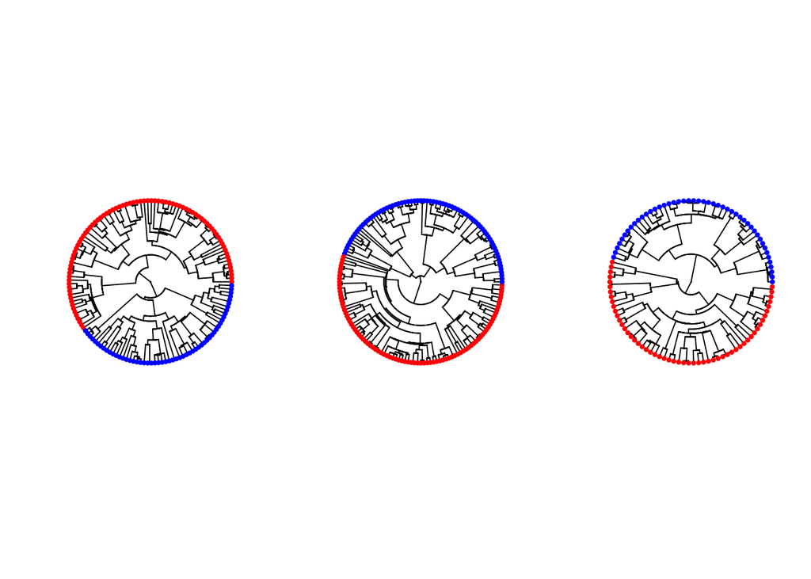

```r
par(mfcol=c(1,3))
for(i in 1:3){
  pick <- sample(1:100, size=1)
  plot(set.phy[[pick]], type = "fan", show.tip.label = F)
  tip.cols <- c("red", "blue")
  ape::tiplabels(pch = 20, col = tip.cols[set.state[[pick]] + 1])
}
```

That looks great just like we want it to!

# the Pagel test in R

[Return to main website](http://coleoguy.github.io/resources.html)

[Return to page 1 of comparative methods](http://coleoguy.github.io/comparative.html)

# citations

[1] Boettiger, Carl, Graham Coop, and Peter Ralph. “Is your phylogeny informative? Measuring the power of comparative methods.” Evolution 66, no. 7 (2012): 2240-2251.

[2] Maddison, Wayne P., and Richard G. FitzJohn. “The unsolved challenge to phylogenetic correlation tests for categorical characters.” Systematic biology 64, no. 1 (2015): 127-136.